# Stat 202: Lecture 15 (covers pp. 171-187)

### Option F: Illustration

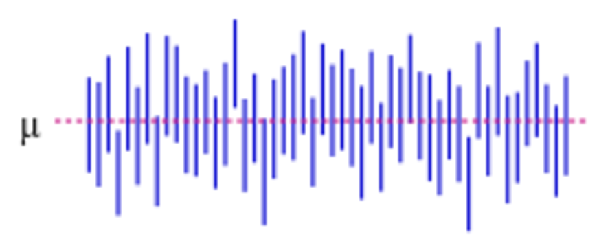

### Option F: Warning

\[ P( \bar{X} - 2 \sigma/n \le \mu \le \bar{X} + 2 \sigma/n) = .95 \]

This probability statement, **however**, is only true when \( \bar{X} \) is currently **unknown**, i.e.

\( \bar{X} \sim N(\mu, \sigma^2/n) \)

If we **do the experiment** we have, say,

\( \bar{x} = 100 \)

which is a **draw** from \( \bar{X} \).

### Option F: Warning

\[ P( \bar{X} - 2 \sigma/n \le \mu \le \bar{X} + 2 \sigma/n) = .95 \]

If we **do the experiment** we have, say, \( \bar{x} = 100 \) with \( 2 \sigma/n = 3 \) then

\[ \begin{aligned} P( \bar{x} - & 2 \sigma/n \le \mu \le \bar{x} + 2 \sigma/n) \\ & = P( 100 - 3 \le \mu \le 100 + 3 ) \\ & = P( 97 \le \mu \le 103 ) \end{aligned} \]

That is weird; \( \mu \) is just a number – **it does not have a distribution**.

### Option F: Warning

The CLT implies that: \[ P( \bar{X} - 2 \sigma/n \le \mu \le \bar{X} + 2 \sigma/n) = .95 \]

Which is not: \( \begin{aligned} P( \bar{x} - & 2 \sigma/n \le \mu \le \bar{x} + 2 \sigma/n) = P( 97 \le \mu \le 103 ) \end{aligned} \)

Remember that \( \mu \) does not have a probability distribution.

If \( \mu = 100 \), then \( P( 97 \le 100 \le 103 ) = 1 \)  
If \( \mu = 95 \), then \( P( 97 \le 95 \le 103 ) = 0 \)

**The interval either contains \( \mu \) or it does not.**

### Option F: Warning

[figure not shown]

Do \[ \begin{aligned} P( \bar{X} & - 2 \sigma/n \le \mu \le \bar{X} + 2 \sigma/n) \\ & = .95 \end{aligned} \]

or do not. There is no try:

\[ \begin{aligned} P( \bar{x} & - 2 \sigma/n \le \mu \le \bar{x} + 2 \sigma/n) \\ & \ne .95 \end{aligned} \]

\( \bar{X} \) is random. You can “reverse” it to say something about \( \mu \). \( \bar{x} \) is **not** random. You cannot say anything about \( \mu \).

### Inference

**Interval estimation**

- Estimating a population quantity with a statistic that is an **interval**.
- Two ways to estimate an interval:
  - **Option F: Confidence Intervals**: If we repeat the experiment over and over, 95% of intervals will contain the true value.
  - **Option B: Credible Intervals**: The probability that the true value is contained within the interval is 95%.

### Confidence v. Credible Intervals

This is awkward:

- Statistician: The 95% confidence interval for \( \mu \) is \( [97,103] \). This means that over many experiments, about 95% of the intervals calculated in this way will contain the true value \( \mu \).
- Normal person: Okay. What's the probability that **this** interval \( [97,103] \) contains \( \mu \)?
- Statistician: I don't know.

### Confidence v. Credible Intervals

Many people are therefore tempted to do the following **\( ^\text{[citation needed]} \)**:

- Statistician: The 95% confidence interval for \( \mu \) is \( [97,103] \). This means that over many experiments …
- Normal person: Okay. What's the probability that **this** interval \( [97,103] \) contains \( \mu \)?
- Statistician: **Well, technically this isn't the right answer, but you can think of it as 95% (more or less)**.

> This is a lie. An “easy” lie, but a lie!

### Credible intervals

Recall that:

- \( \bar{X} \) is random. You can “reverse” it to say something about a non-random \( \mu \).
- \( \bar{x} \) is **not** random. You cannot say anything about a non-random \( \mu \).

What if \( \mu \) was modeled as, itself, random?

### Credible intervals

If \( \mu \) were random, then we could use Bayes Rule to update our beliefs about \( \mu \) after we have seen the data.

Therefore, we can do this \[ \begin{aligned} P( 97 \le \mu \le 103 \quad | \quad \text{data}) \end{aligned} \] i.e., the probability that \( \mu \) is contained in the interval (once we have seen the data!), can be calculated.

> Neither Stat 202 (nor most statistics textbooks!) teach it. **Take a Bayesian statistics course!**

### Credible intervals (if time)

How it works:

1. Research the system that you are modeling.
2. Create a model for the data, given the parameter values: \( P(x|\mu) \)
3. Summarize your research (likely mean, uncertainty about what the mean is) into a distribution for \( \mu \). This is the **prior**: \( P(\mu) \)
4. Do the experiment and get the data: \( x \)
5. Use Bayes' Rule to reverse \( P(x|\mu) \) to \( P(\mu|x) \)
6. Answer probability questions about what the values of \( \mu \) **after having seen the data** are.

### Inference

**Interval estimation**

- Estimating a population quantity with a statistic that is an **interval**.
- Two ways to estimate an interval:
  - **Option F: Confidence Intervals**: If we repeat the experiment over and over, 95% of intervals will contain the true value.
  - **Option B: Credible Intervals**: The probability that the true value is contained within the interval is 95%.

### More with Option F

In Stat 202, we will focus on confidence intervals.

If the data are normally distributed with an **unkonwn** mean \( \mu \) and a **known** standard deviation \( \sigma \), then, a 95% confidence interval for \( \mu \) is

- \( \bar{x} \pm 2 \sigma /\sqrt{n} \)

If the are distributed with an **unknown** mean \( \mu \) and a **known** standard deviation \( \sigma \), then, if \( n \ge 30 \), a 95% confidence interval is

- \( \bar{x} \pm 2 \sigma /\sqrt{n} \)

### More with Option F

If you want a different confidence interval, you change the **2**.

A 68% confidence interval:

- \( \bar{x} \pm 1 \sigma /\sqrt{n} \)

A 95% confidence interval:

- \( \bar{x} \pm 2 \sigma /\sqrt{n} \)

A 99.7% confidence interval:

- \( \bar{x} \pm 3 \sigma /\sqrt{n} \)

**Note:** Higher levels of confidence have less precise intervals.

### More with Option F

If you want a different confidence interval, you change the **2**.

A 95% confidence interval:

- \( \bar{x} \pm 2 \sigma /\sqrt{n} \)

A \( (1-\alpha) \times 100\% \) confidence interval:

- \( \bar{x} \pm z_{\alpha/2} \cdot \sigma /\sqrt{n} \)

(on the board)

**Definition:** \( z_{\alpha/2} \cdot \sigma /\sqrt{n} \) is the **margin of error**.

### More with Option F

If you want to plan a study, you solve for \( n \)

IQ scores are known to vary normally with a standard deviation of 15. How many students should be sampled if we want to estimate the population mean IQ at 99% confidence with a margin of error equal to 2?

(on board)

### More with Option F

If you want to plan a study with a margin of error \( m \), you solve for \( n \)

\[ n = \left( \frac{z_{\alpha/2} \cdot \sigma}{m} \right)^2 \]

and then round up to the nearest integer.

**Note:** Higher values of \( n \) give **more** precise intervals.

### Option F Summary

In Stat 202, we will focus on confidence intervals.

If the data are normally distributed with an **unkonwn** mean \( \mu \) and a **known** standard deviation \( \sigma \), then, a 95% confidence interval for \( \mu \) is

- \( \bar{x} \pm 2 \sigma /\sqrt{n} \)

If the are distributed with an **unknown** mean \( \mu \) and a **known** standard deviation \( \sigma \), then, if \( n \ge 30 \), a 95% confidence interval is

- \( \bar{x} \pm 2 \sigma /\sqrt{n} \)

**Note:** The book covers cases with unknown standard deviation. We will not cover this yet.

### A cold read exercise

Can I have two volunteers to read from a script?

(Time permitting.)

### A dialogue

Person: Can you give me an interval that will contain \( \mu \) with 95% probability?

Stat F: Sure, I can give you a confidence interval. Over 100 replications of your experiment, 95% of the confidence intervals with contain \( \mu \).

Person: Sorry, I misspoke. I want to perform one experiment, calculate an interval, and know that there is a 95% chance that \( \mu \) is in that interval.

Stat F: [as a smarty-pants] Ah! I see that you have a common misconception of what a confidence interval is. Let me try to explain it again…

### A dialogue

Person: [interrupting, frustrated] No, no, no. I am smart person who understood what you said. It is, however, clear to me that you do not understand what I am asking …

[Enter Statistician B]

**Stat B**: Hi! I overheard you talking to my colleague that you want an interval that will contain \( \mu \) with 95% probability?

Person: Yes! Finally, a statistician who understands what I am asking!

### A dialogue

Stat F: [freaked out] Wait! Stop! He is the devil!

Person: [confused] What, why?

Stat F: He will use **calculus** and **computer programming**!

Person: [confused stare] ?

Stat F: He will make you specify how you expect your experiment to turn out!

Person: [confused] Wouldn't you ask me the same questions for a sample size calculation?

### A dialogue

Stat F: Yes, but he will actually use your opinions instead of ignoring them like I do! Your result might not be objective! It might be influenced by what you believe!

Person: [confused stare] ?

**Stat B:** Ah, my dear colleague, but I will answer the question that is asked instead of insisting on answering a different question.

[Stat F is so frustrated as to die an exaggerated theatrical death.]